# Principal Component Analysis

Dataset Energia1

This dataset contains 24 individuals and 14 variables.

### 1. Study of the outliers

The analysis of the graphs does not detect any outlier.

### 2. Inertia distribution

The inertia of the first dimensions shows if there are strong relationships between variables and suggests the number of dimensions that should be studied.

The first two dimensions of analyse express **65.38%** of the total dataset inertia ; that means that 65.38% of the individuals (or variables) cloud total variability is explained by the plane. This percentage is relatively high and thus the first plane well represents the data variability. This value is strongly greater than the reference value that equals **37.56%**, the variability explained by this plane is thus highly significant (the reference value is the 0.95-quantile of the inertia percentages distribution obtained by simulating 1063 data tables of equivalent size on the basis of a normal distribution).

From these observations, it should be better to also interpret the dimensions greater or equal to the third one.

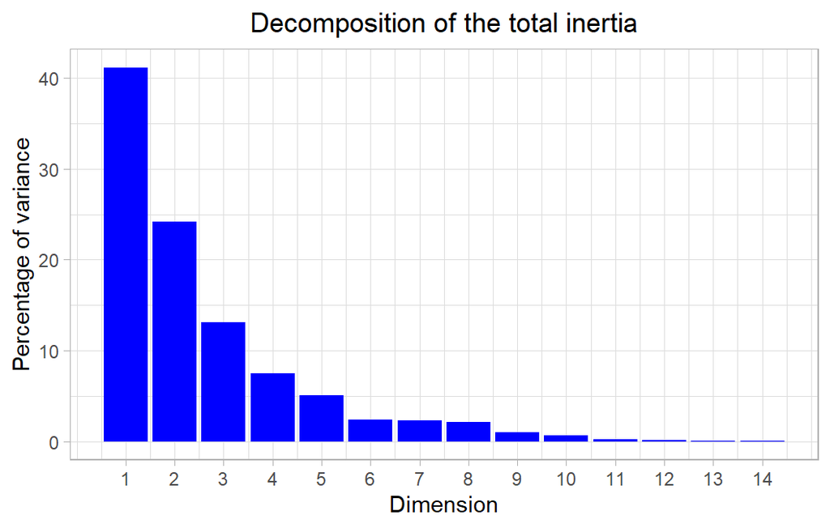

**Figure 2 - Decomposition of the total inertia**

An estimation of the right number of axis to interpret suggests to restrict the analysis to the description of the first 3 axis. These axis present an amount of inertia greater than those obtained by the 0.95-quantile of random distributions (78.48% against 50.66%). This observation suggests that only these axis are carrying a real information. As a consequence, the description will stand to these axis.

### 3. Description of the plane 1:2

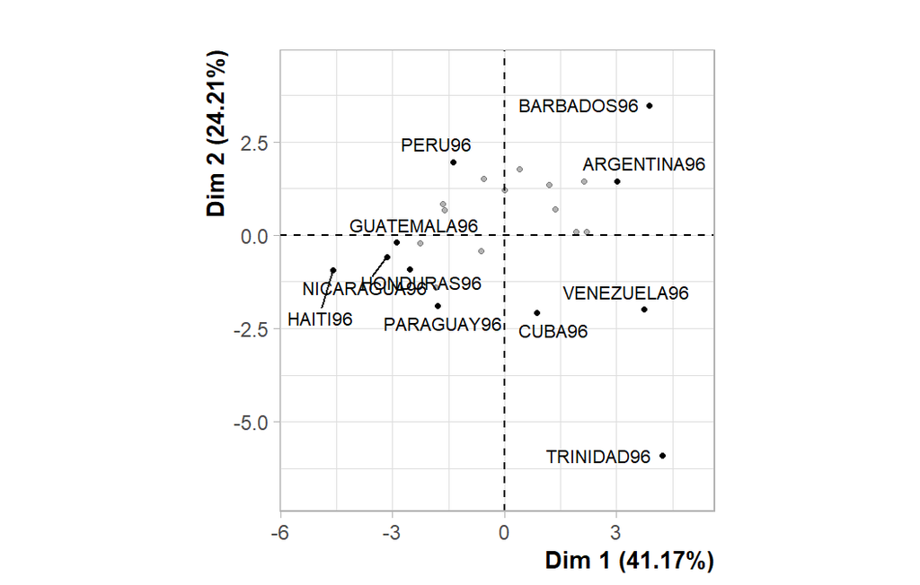

**Figure 3.1 - Individuals factor map (PCA)** *The labeled individuals are those with the higher contribution to the plane construction.*

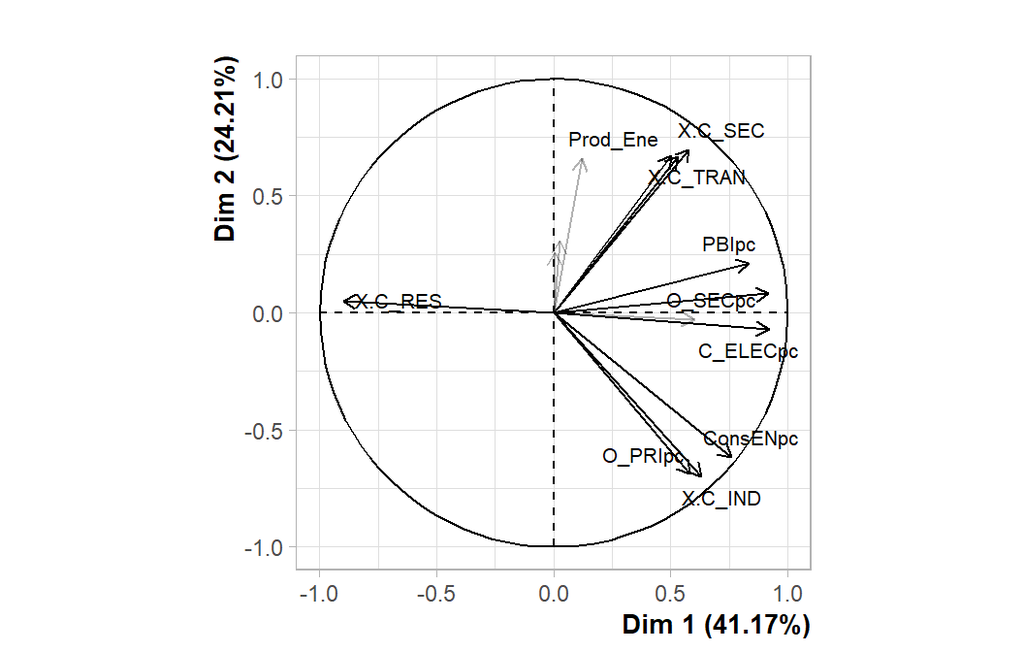

**Figure 3.2 - Variables factor map (PCA)** *The labeled variables are those the best shown on the plane.*

The **dimension 1** opposes individuals such as *TRINIDAD96*, *BARBADOS96*, *VENEZUELA96* and *ARGENTINA96* (to the right of the graph, characterized by a strongly positive coordinate on the axis) to individuals such as *HAITI96*, *GUATEMALA96*, *NICARAGUA96*, *HONDURAS96* and *PARAGUAY96* (to the left of the graph, characterized by a strongly negative coordinate on the axis).

The group in which the individuals *BARBADOS96* and *ARGENTINA96* stand (characterized by a positive coordinate on the axis) is sharing :

- high values for the variables *X.C_SEC*, *Prod_Ind*, *X.C_TRAN*, *Prod_Ene*, *PBIpc* and *O_SECpc* (variables are sorted from the strongest).

The group in which the individuals *TRINIDAD96* and *VENEZUELA96* stand (characterized by a positive coordinate on the axis) is sharing :

- high values for the variables *O_PRIpc*, *ConsENpc*, *X.C_IND* and *C_ELECpc* (variables are sorted from the strongest).

The group in which the individuals *HAITI96*, *GUATEMALA96*, *NICARAGUA96*, *HONDURAS96* and *PARAGUAY96* stand (characterized by a negative coordinate on the axis) is sharing :

- high values for the variable *X.C_RES*.
- low values for the variables *C_ELECpc*, *O_SECpc*, *PBIpc*, *X.C_TRAN*, *X.C_SEC*, *ConsENpc*, *Prod_Ene*, *Prod_Ind* and *X.C_IND* (variables are sorted from the weakest).

The **dimension 2** opposes individuals such as *BARBADOS96* and *ARGENTINA96* (to the top of the graph, characterized by a strongly positive coordinate on the axis) to individuals such as *TRINIDAD96* and *VENEZUELA96* (to the bottom of the graph, characterized by a strongly negative coordinate on the axis).

The group in which the individuals *BARBADOS96* and *ARGENTINA96* stand (characterized by a positive coordinate on the axis) is sharing :

- high values for the variables *X.C_SEC*, *Prod_Ind*, *X.C_TRAN*, *Prod_Ene*, *PBIpc* and *O_SECpc* (variables are sorted from the strongest).

The group in which the individuals *TRINIDAD96* and *VENEZUELA96* stand (characterized by a negative coordinate on the axis) is sharing :

- high values for the variables *O_PRIpc*, *ConsENpc*, *X.C_IND* and *C_ELECpc* (variables are sorted from the strongest).

### 4. Description of the dimension 3

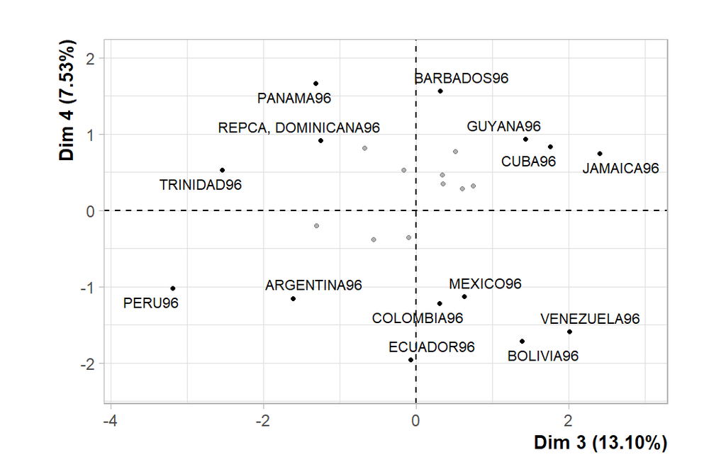

**Figure 4.1 - Individuals factor map (PCA)** *The labeled individuals are those with the higher contribution to the plane construction.*

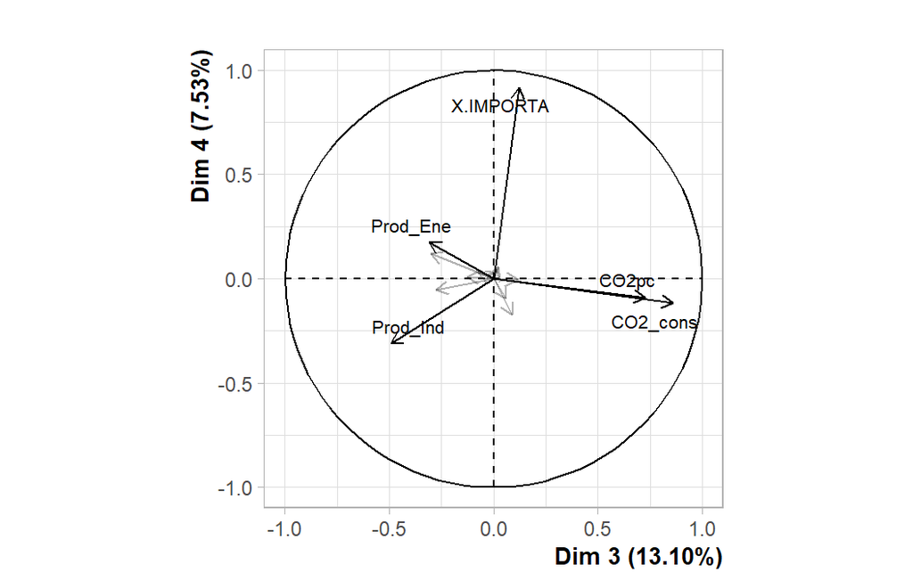

**Figure 4.2 - Variables factor map (PCA)** *The labeled variables are those the best shown on the plane.*

The group in which the individuals *JAMAICA96*, *GUYANA96* and *CUBA96* stand (characterized by a positive coordinate on the axis) is sharing :

- variables whose values do not differ significantly from the mean.

The group in which the individual *PERU96* stands (characterized by a negative coordinate on the axis) is sharing :

- high values for the variable *Prod_Ind*.

### 5. Classification

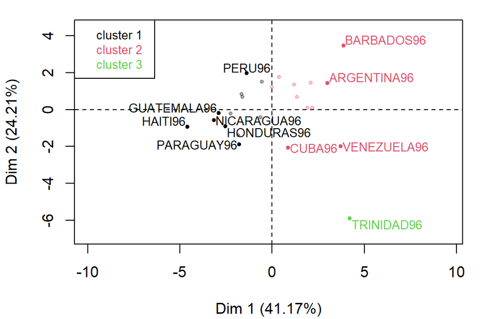

**Figure 5 - Ascending Hierarchical Classification of the individuals.** *The classification made on individuals reveals 3 clusters.*

The **cluster 1** is made of individuals such as *GUATEMALA96*, *HAITI96*, *HONDURAS96*, *NICARAGUA96*, *PARAGUAY96* and *PERU96*. This group is characterized by :

- high values for the variable *X.C_RES*.
- low values for the variables *C_ELECpc*, *O_SECpc*, *PBIpc*, *ConsENpc*, *X.C_SEC*, *CO2pc*, *X.C_IND*, *X.C_TRAN* and *Prod_Ene* (variables are sorted from the weakest).

The **cluster 2** is made of individuals such as *ARGENTINA96*, *BARBADOS96*, *CUBA96* and *VENEZUELA96*. This group is characterized by :

- high values for the variables *O_SECpc*, *X.C_SEC*, *C_ELECpc*, *X.C_TRAN*, *PBIpc*, *CO2pc* and *Prod_Ene* (variables are sorted from the strongest).
- low values for the variable *X.C_RES*.

The **cluster 3** is made of individuals such as *TRINIDAD96*. This group is characterized by :

- high values for the variables *O_PRIpc*, *ConsENpc* and *X.C_IND* (variables are sorted from the strongest).

## Annexes

```r
dimdesc(res, axes = 1:3)
```

```
$Dim.1
$quanti
         correlation      p.value
C_ELECpc   0.9200784 2.016315e-10
O_SECpc    0.9193069 2.232884e-10
PBIpc      0.8351796 3.837551e-07
ConsENpc   0.7614418 1.548584e-05
X.C_IND    0.6313640 9.375244e-04
CO2pc      0.6016601 1.869667e-03
O_PRIpc    0.5828394 2.799977e-03
X.C_SEC    0.5789886 3.032225e-03
X.C_TRAN   0.5302409 7.692024e-03
Prod_Ene   0.5037782 1.207774e-02
X.C_RES   -0.8996418 2.238852e-09

attr(,"class")
[1] "condes" "list"

$Dim.2
$quanti
         correlation      p.value
X.C_SEC    0.6987759 0.0001456736
Prod_Ene   0.6724106 0.0003189571
X.C_TRAN   0.6690399 0.0003506285
Prod_Ind   0.6595851 0.0004544623
ConsENpc  -0.6163891 0.0013391346
O_PRIpc   -0.6883457 0.0002005201
X.C_IND   -0.7008540 0.0001364725

attr(,"class")
[1] "condes" "list"

$Dim.3
$quanti
         correlation      p.value
CO2_cons   0.8584242 8.078137e-08
CO2pc      0.7283229 5.458585e-05
Prod_Ind  -0.4942174 1.409768e-02

attr(,"class")
```

[output cut: 73 more lines]

```
EL _SALVADOR96        569.19 0.357151911
GUATEMALA96           281.43 0.323751923
GUYANA96              374.70 0.433103698
HAITI96                52.66 0.128743244
HONDURAS96            437.22 0.376416337
JAMAICA96            2254.16 0.590826113
MEXICO96             1549.32 0.047869410
NICARAGUA96           365.55 0.309499352
PANAMA96             1210.12 0.590214512
PARAGUAY96            325.92 0.106302561
PERU96                629.56 0.202146362
REPCA, DOMINICANA96   782.69 0.453946806
TRINIDAD96           2926.83 0.175097393
URUGUAY96            2384.05 0.434223083
VENEZUELA96          3036.17 0.001650128
```

**Figure 6 - List of variables characterizing the dimensions of the analysis.**

```r
res.hcpc$desc.var
```

```
Link between the cluster variable and the quantitative variables
================================================================
              Eta2      P-value
O_PRIpc  0.8606395 1.031493e-09
ConsENpc 0.7907909 7.346763e-08
C_ELECpc 0.7396100 7.312307e-07
O_SECpc  0.6456878 1.855900e-05
X.C_RES  0.6294488 2.971024e-05
X.C_IND  0.5789818 1.135426e-04
X.C_SEC  0.5535890 2.099987e-04
PBIpc    0.5523655 2.161211e-04
X.C_TRAN 0.4173883 3.439393e-03
CO2pc    0.3366472 1.343749e-02
Prod_Ene 0.2594740 4.267498e-02

Description of each cluster by quantitative variables
=====================================================
$`1`
            v.test Mean in category Overall mean sd in category   Overall sd
X.C_RES   3.712727        0.4580333    0.3204583   1.365018e-01    0.1777094
Prod_Ene -2.215204        0.2770250    0.3878042   1.201831e-01    0.2398326
X.C_TRAN -2.408570        0.2507417    0.2961000   7.699872e-02    0.0903154
X.C_IND  -2.489696        0.2149750    0.2940250   8.094213e-02    0.1522718
CO2pc    -2.514517     1397.3333333 2068.0941667   7.013066e+02 1279.3134825
X.C_SEC  -2.819313        0.5257000    0.6389500   1.448705e-01    0.1926455
ConsENpc -2.877472     3654.3266667 5568.1983333   1.085723e+03 3189.8162655
PBIpc    -3.488399      998.4375000 2154.1987500   4.419693e+02 1588.9342608
O_SECpc  -3.851101     2473.5216667 5135.1412500   9.662379e+02 3314.5529694
C_ELECpc -3.975146      509.9758333 1242.9062500   2.964636e+02  884.2468618
              p.value
X.C_RES  2.050380e-04
Prod_Ene 2.674607e-02
X.C_TRAN 1.601517e-02
X.C_IND  1.278525e-02
CO2pc    1.191954e-02
X.C_SEC  4.812650e-03
ConsENpc 4.008759e-03
PBIpc    4.859229e-04
O_SECpc  1.175879e-04
C_ELECpc 7.033595e-05
```

[output cut: 15 more lines]

```
X.C_TRAN 0.0028821572
PBIpc    0.0034797249
CO2pc    0.0054286509
Prod_Ene 0.0146196508
X.C_RES  0.0020103671

$`3`
           v.test Mean in category Overall mean sd in category   Overall sd
O_PRIpc  4.343365       70309.2100  9657.005833              0 1.396434e+04
ConsENpc 3.678557       17302.1200  5568.198333              0 3.189816e+03
X.C_IND  3.128451           0.7704     0.294025              0 1.522718e-01
              p.value
O_PRIpc  1.403169e-05
ConsENpc 2.345571e-04
X.C_IND  1.757300e-03
```

**Figure 7 - List of variables characterizing the clusters of the classification.**